# Lecture 13 - Theory and Homework

This is an [R Markdown](http://rmarkdown.rstudio.com) Notebook

### Lecture 13 - What Data and Manipulation Data

#### We can review the data first…

Pay attention to the column names in those tables. Are some of them common?

```r
library(tidyverse)
# data frame containing information from multiple sensors
read_csv("DF_Data.csv") %>% head(3)
```

```
## # A tibble: 3 x 5
##   RowNumber       StartDateTime EventCode IDEquipment TimeTotal
##       <int>              <time>     <int>       <int>     <int>
## 1         1 2016-11-17 05:08:07 103007090           3        69
## 2         2 2016-11-17 06:23:02 103007090           3        51
## 3         3 2016-11-17 07:08:19 103007090           3        76
```

```r
# data frame containing equipment information
read_csv("DF_EquipmData.csv") %>% head(3)
```

```
## # A tibble: 3 x 2
##   IDEquipment       Name
##         <int>      <chr>
## 1           3 Machine #1
## 2          13 Machine #2
## 3          23 Machine #3
```

```r
# data frame containing Event Names
read_csv("DF_EvCodeData.csv") %>% head(3)
```

```
## # A tibble: 3 x 2
##   EventCode        EventText
##       <int>            <chr>
## 1 103007050 Step 1 SubStep 1
## 2 103007070 Step 1 SubStep 2
## 3 103007080 Step 1 SubStep 3
```

#### Manipulate data

Run the code from the App directly

```r
# data frame containing equipment information
DF_Equipm <- read_csv("DF_EquipmData.csv")
# data frame containing Event Names
DF_EvCode <- read_csv("DF_EvCodeData.csv")
```

```r
# Data manipulation and saving to the DF_TEMP
DF_TEMP <- read_csv("DF_Data.csv") %>%
  # arrange by date
  arrange(StartDateTime) %>%
  # join to decode equipment serial number
  inner_join(DF_Equipm, by = "IDEquipment") %>%
  # select only column needed
  select(StartDateTime, Name, EventCode, TimeTotal) %>%
  # join to decode Event Code meaning
  inner_join(DF_EvCode, by = "EventCode") %>%
  # select only column needed
  select(StartDateTime, Name, EventCode, TimeTotal, EventText)
# =================================
#
head(DF_TEMP)
```

```
## # A tibble: 6 x 5
##         StartDateTime       Name EventCode TimeTotal        EventText
##                <time>      <chr>     <int>     <int>            <chr>
## 1 2016-10-25 00:14:40 Machine #1 103007090        58 Step 1 SubStep 4
## 2 2016-10-25 01:06:16 Machine #1 103007090        95 Step 1 SubStep 4
## 3 2016-10-25 02:30:32 Machine #1 103007090       485 Step 1 SubStep 4
## 4 2016-10-25 04:50:16 Machine #1 103007090       130 Step 1 SubStep 4
## 5 2016-10-25 07:19:06 Machine #1 103007090       270 Step 1 SubStep 4
## 6 2016-10-25 07:23:36 Machine #1 103007080         5 Step 1 SubStep 3
```

As you see we have now Start Time, Name of the Machine, time total and event text. This is definitely will not be easy to comprehend by human eye as is. However as you will see this structure is good for creating visualizations using data graphic grammar of ggplot2

#### Data manipulation step by step

Let’s review how did we get this step by step… in particular, notice using the construct `%>%` called `pipe`. It is passing the **result** from the calculations to the first argument of the next function. Last function we will use `head()` is just to reduce the output for our `R Notebook`

```r
# read data and arrange by start date time and ouput only 6 rows...
read_csv("DF_Data.csv") %>%
  # arrange by date
  arrange(StartDateTime) %>% head()
```

```
## # A tibble: 6 x 5
##   RowNumber       StartDateTime EventCode IDEquipment TimeTotal
##       <int>              <time>     <int>       <int>     <int>
## 1       186 2016-10-25 00:14:40 103007090           3        58
## 2       187 2016-10-25 01:06:16 103007090           3        95
## 3       188 2016-10-25 02:30:32 103007090           3       485
## 4       189 2016-10-25 04:50:16 103007090           3       130
## 5       190 2016-10-25 07:19:06 103007090           3       270
## 6       191 2016-10-25 07:23:36 103007080           3         5
```

Now we ‘join’ the IDEquipment table … notice that Column **Name** will be added with all information we need to understand what machine number it is representing in reality…

```r
read_csv("DF_Data.csv") %>%
  # arrange by date
  arrange(StartDateTime) %>%
  # join to decode equipment serial number
  inner_join(DF_Equipm, by = "IDEquipment") %>% head()
```

```
## # A tibble: 6 x 6
##   RowNumber       StartDateTime EventCode IDEquipment TimeTotal       Name
##       <int>              <time>     <int>       <int>     <int>      <chr>
## 1       186 2016-10-25 00:14:40 103007090           3        58 Machine #1
## 2       187 2016-10-25 01:06:16 103007090           3        95 Machine #1
## 3       188 2016-10-25 02:30:32 103007090           3       485 Machine #1
## 4       189 2016-10-25 04:50:16 103007090           3       130 Machine #1
## 5       190 2016-10-25 07:19:06 103007090           3       270 Machine #1
## 6       191 2016-10-25 07:23:36 103007080           3         5 Machine #1
```

Now we will repeat exact same for Event Code…

```r
read_csv("DF_Data.csv") %>%
  # arrange by date
  arrange(StartDateTime) %>%
  # join to decode equipment serial number
  inner_join(DF_Equipm, by = "IDEquipment") %>%
  # select only column needed
  select(StartDateTime, Name, EventCode, TimeTotal) %>%
  # join to decode Event Code meaning
  inner_join(DF_EvCode, by = "EventCode") %>% head()
```

```
## # A tibble: 6 x 5
##         StartDateTime       Name EventCode TimeTotal        EventText
##                <time>      <chr>     <int>     <int>            <chr>
## 1 2016-10-25 00:14:40 Machine #1 103007090        58 Step 1 SubStep 4
## 2 2016-10-25 01:06:16 Machine #1 103007090        95 Step 1 SubStep 4
## 3 2016-10-25 02:30:32 Machine #1 103007090       485 Step 1 SubStep 4
## 4 2016-10-25 04:50:16 Machine #1 103007090       130 Step 1 SubStep 4
## 5 2016-10-25 07:19:06 Machine #1 103007090       270 Step 1 SubStep 4
## 6 2016-10-25 07:23:36 Machine #1 103007080         5 Step 1 SubStep 3
```

now we will select only columns we will need…

```r
read_csv("DF_Data.csv") %>%
  # arrange by date
  arrange(StartDateTime) %>%
  # join to decode equipment serial number
  inner_join(DF_Equipm, by = "IDEquipment") %>%
  # select only column needed
  select(StartDateTime, Name, EventCode, TimeTotal) %>%
  # join to decode Event Code meaning
  inner_join(DF_EvCode, by = "EventCode") %>%
  # select only column needed
  select(StartDateTime, TimeTotal, Name, EventText) %>% head()
```

```
## # A tibble: 6 x 4
##         StartDateTime TimeTotal       Name        EventText
##                <time>     <int>      <chr>            <chr>
## 1 2016-10-25 00:14:40        58 Machine #1 Step 1 SubStep 4
## 2 2016-10-25 01:06:16        95 Machine #1 Step 1 SubStep 4
## 3 2016-10-25 02:30:32       485 Machine #1 Step 1 SubStep 4
## 4 2016-10-25 04:50:16       130 Machine #1 Step 1 SubStep 4
## 5 2016-10-25 07:19:06       270 Machine #1 Step 1 SubStep 4
## 6 2016-10-25 07:23:36         5 Machine #1 Step 1 SubStep 3
```

This way we have prepared our data for visualization

#### Visualisation with facets

This code snippet would plot our data:

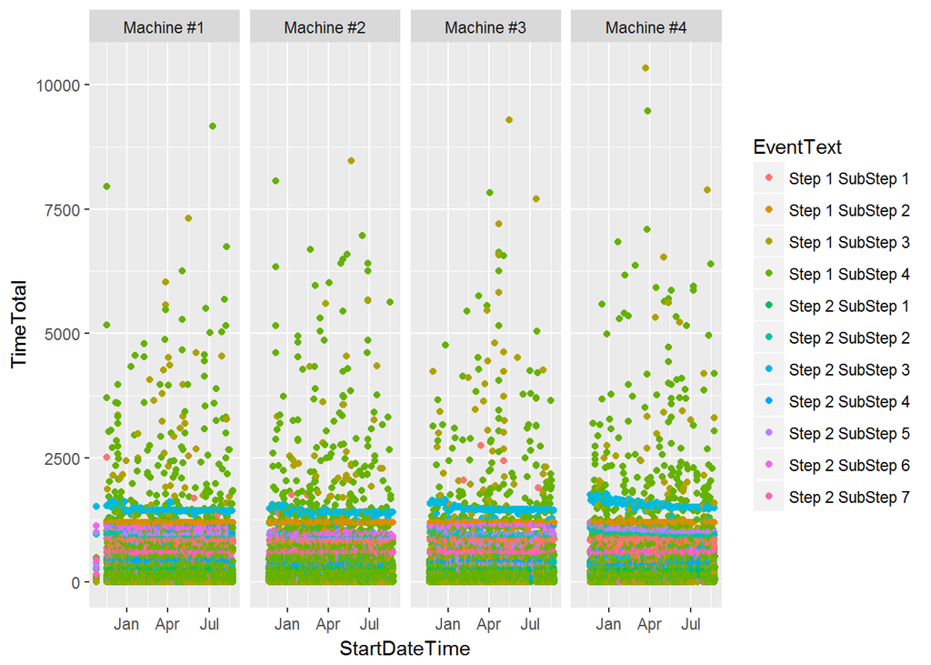

```r
read_csv("DF_Data.csv") %>%
  # join to decode equipment serial number
  inner_join(DF_Equipm, by = "IDEquipment") %>%
  # select only column needed
  select(StartDateTime, Name, EventCode, TimeTotal) %>%
  # join to decode Event Code meaning
  inner_join(DF_EvCode, by = "EventCode") %>%
  # select only column needed
  select(StartDateTime, TimeTotal, Name, EventText) %>%
  # arrange by date
  arrange(StartDateTime) %>%
  # make a plot
  ggplot(aes(x = StartDateTime, y = TimeTotal, col = EventText)) + geom_point()+
  facet_grid(.~Name)
```

Seems like it’s hard to get some good understanding on what is going on, isn’t it?